# R Notebook

101.5 This is a bit p-hacky, but also prescedented by my Nyvac study. I want to run a logistic regression on every taxon, at every taxonomic level, to find some exemplars of things that seem to relate to crashes. (adjusting vor multiple comparasons)

I’d like to see if any of those “predictive” (positive sign) bugs increase in abundance as the crash progresses.

```r
source("Initial_Processing.R")
library(purrr)
library(broom)
```

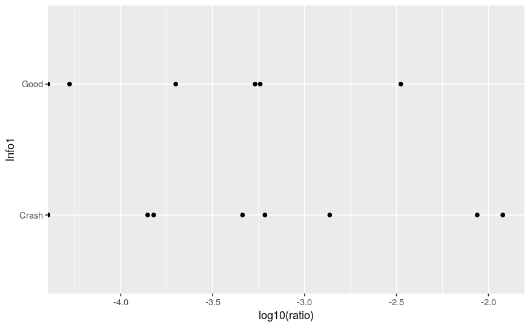

```r
test_asv <- early %>% filter(ASV == "ASV_4") %>%
  mutate(isCrash = Info1 == "Crash")
test_asv[test_asv$ratio > 0,]$ratio %>% min() -> rat_min
ggplot(data = test_asv, aes(x = log10(ratio), y = Info1)) + geom_point()
```

```r
test_mod <- glm(isCrash ~ log10(ratio + rat_min), data = test_asv, family = "binomial")
summary(test_mod)
```

```
Call:
glm(formula = isCrash ~ log10(ratio + rat_min), family = "binomial",
    data = test_asv)

Deviance Residuals:
    Min       1Q   Median       3Q      Max
-1.5117  -1.2785   0.8183   1.0321   1.1608

Coefficients:
                       Estimate Std. Error z value Pr(>|z|)
(Intercept)              1.7410     2.5735   0.676    0.499
log10(ratio + rat_min)   0.3978     0.7444   0.534    0.593

(Dispersion parameter for binomial family taken to be 1)

    Null deviance: 20.190  on 14  degrees of freedom
Residual deviance: 19.895  on 13  degrees of freedom
AIC: 23.895

Number of Fisher Scoring iterations: 4
```

```r
my_logistic_glm <- function(df){glm(isCrash ~ log10(ratio + rat_min), data = df, family = "binomial")}
quiet_logistic_glm <- quietly(my_logistic_glm)

asv_models <- early %>%
  mutate(isCrash = Info1 == "Crash") %>%
  group_by(ASV) %>%
  nest() %>%
  mutate(modLs = map(data, quiet_logistic_glm)) %>%
  mutate(mod = map(modLs, ~.[["result"]]),
         warn = map(modLs, ~.[["warnings"]]), # map_chr cant handle zero length vectors
         tid = map(mod, tidy)
         ) %>%
  identity()
```

```r
asv_model_data <- asv_models %>%
  select(ASV, tid) %>%
  unnest(tid) %>%
  filter(term != "(Intercept)")

asv_model_ok <- asv_model_data %>%
  filter(`p.value` < 0.05)
asv_model_ok
```

| ASV | term | estimate | std.error | statistic | p.value |
| --- | --- | --- | --- | --- | --- |

Hah! Nothing comes close to predicting crashes.

# What about after the crashes

```r
many_logistic <- function(fort, gb = ASV){
  asv_models <- fort %>%
  mutate(isCrash = Info1 == "Crash") %>%
  group_by({{gb}}) %>% # or gtax
  nest() %>%
  mutate(modLs = map(data, quiet_logistic_glm)) %>%
  mutate(mod = map(modLs, ~.[["result"]]),
         warn = map(modLs, ~.[["warnings"]]), # map_chr cant handle zero length vectors
         tid = map(mod, tidy)
         ) %>%
  identity()

  asv_model_data <- asv_models %>%
  select({{gb}}, tid) %>%
  unnest(tid) %>%
  filter(term != "(Intercept)")
}
```

```r
asv_model_group_test <- many_logistic(early, Family)
```

[output not shown]

```r
n
```

```
debug at #2: asv_models <- fort %>% mutate(isCrash = Info1 == "Crash") %>%
    group_by({
        {
            gb
        }
    }) %>% nest() %>% mutate(modLs = map(data, quiet_logistic_glm)) %>%
    mutate(mod = map(modLs, ~.[["result"]]), warn = map(modLs,
        ~.[["warnings"]]), tid = map(mod, tidy)) %>% identity()
```

```r
  asv_models <- fort %>%
  mutate(isCrash = Info1 == "Crash") %>%
  group_by({{gb}}) %>% # or gtax
  nest()
View(asv_models)
1
```

```
[1] 1
```

```r
View(asv_models[[2]][[2]])
Q
```

```r
asv_model_data_01 <- many_logistic(early)
asv_model_data_01 %>% filter(p.value < 0.05)
```

| ASV | term | estimate | std.error | statistic | p.value |
| --- | --- | --- | --- | --- | --- |

```r
asv_model_data_mid <- many_logistic(mid)
asv_model_data_mid_ok <- asv_model_data_mid %>% filter(p.value < 0.05)
asv_model_data_mid_ok
```

| ASV | term | estimate | std.error | statistic | p.value |
| --- | --- | --- | --- | --- | --- |
| ASV_6 | log10(ratio + rat_min) | 1.190636 | 0.6042025 | 1.970591 | 0.04877062 |

One weak thing.

# What about by different taxonomic levels

Test group taxa

```r
group_taxa_2(early, "Family")
```

[output not shown]

[output cut: 990 more lines]

```r
taxLevels <- c("Kingdom", "Phylum", "Class", "Order", "Family", "Genus")
glomThing <- tibble(taxLevel = taxLevels) %>%
  mutate(data1 = map(taxLevel, ~group_taxa_2(early, .)))
```

```r
glomThing_2 <- glomThing %>%
  mutate(data2 = map(data1, many_logistic)) %>% # I should modify many_logistic to group by the named level
  unnest(data2) %>%
  select(-data1)
```

Ok this is silly, everything is named by the first asv in the group still, but should still work-ish

Something isn’t making sense in the output here. Why aren’t there coherent groups?

```r
glomThing_2 %>% filter(p.value < 0.05)
```

| taxLevel | ASV | term | estimate | std.error | statistic | p.value |
| --- | --- | --- | --- | --- | --- | --- |

Nothing

# And mid?

```r
taxLevels <- c("Kingdom", "Phylum", "Class", "Order", "Family", "Genus")
glomThing <- tibble(taxLevel = taxLevels) %>%
  mutate(data1 = map(taxLevel, ~group_taxa_2(mid, .)))
```

# Debug here and in many logistic